# Early life history respirometry (photosynthesis & respiration) analysis and plotting

AS Huffmyer

2020

## **Setup**

Set up workspace, set options, and load required packages.

```r
rm(list=ls(all=TRUE))
```

```r
## install packages if you dont already have them in your library
if ("tidyverse" %in% rownames(installed.packages()) == 'FALSE') install.packages('tidyverse')
if ("car" %in% rownames(installed.packages()) == 'FALSE') install.packages('car')
if ("lme4" %in% rownames(installed.packages()) == 'FALSE') install.packages('lme4')
if ("lmerTest" %in% rownames(installed.packages()) == 'FALSE') install.packages('lmerTest')
if ("scales" %in% rownames(installed.packages()) == 'FALSE') install.packages('scales')
if ("cowplot" %in% rownames(installed.packages()) == 'FALSE') install.packages('cowplot')
if ("ggplot2" %in% rownames(installed.packages()) == 'FALSE') install.packages('ggplot2')
if ("effects" %in% rownames(installed.packages()) == 'FALSE') install.packages('effects')

#load packages
library("ggplot2")
library("tidyverse")
library('car')
library('lme4')
library('lmerTest')
library('scales')
library('cowplot')
library('effects')
```

## **Data visualization and manipulation**

Load data from LoLinR.

```r
PRdata<-read.csv("../../Ahya2020/Output/Respiration/oxygen_P_R_calc.csv") #load data
```

Separate project specific data.

```r
#remove all rows of wells that did not have samples or blanks
PRdata<-PRdata[!is.na(PRdata$Type),]

#format columns
PRdata$dpf<-as.factor(PRdata$dpf)
```

Calculate a P:R ratio using gross photosynthesis.

```r
PRdata$ratio<-(PRdata$GP.nmol.org.min)/abs(PRdata$R.nmol.org.min) #calculate ratio with absolute values
#remove outliers detected by values of P:R ratio data
```

## **Plotting: Larvae**

Generate plots by days post fertilization.

### *Respiration*

Examine data.

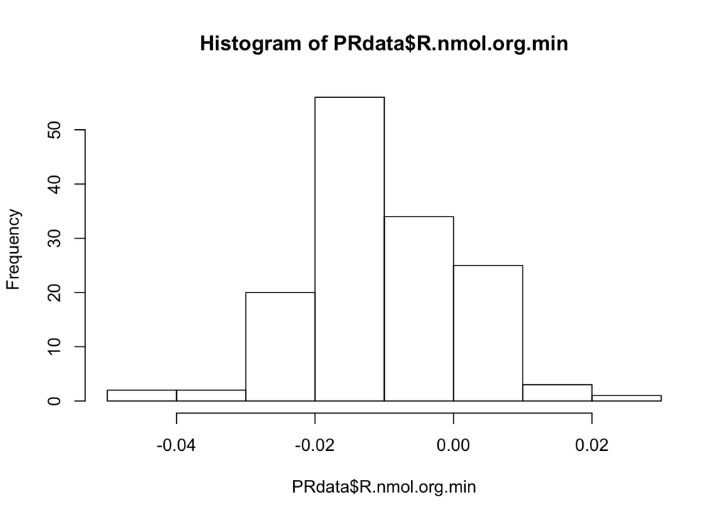

```r
hist(PRdata$R.nmol.org.min)
```

Generate dot plot.

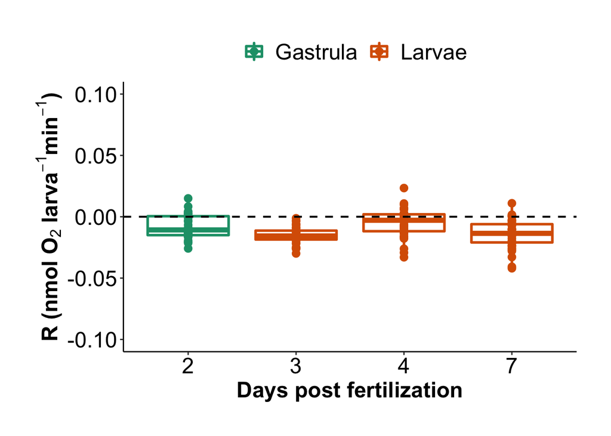

```r
Rplot1<-ggplot(data=PRdata, aes(x=dpf, y=R.nmol.org.min, colour=Stage, group=interaction(Stage, dpf))) +
  geom_boxplot(position=position_dodge(0.9), lwd=1)+
  geom_jitter(shape=16, position=position_dodge(0.9), size=3)+
  geom_hline(yintercept=0, linetype="dashed", color="black", size=0.75)+
  scale_color_brewer(palette = "Dark2", breaks=c("Gastrula", "Larvae"))+
  scale_y_continuous(limits=c(-0.1, 0.1), labels = scales::number_format(accuracy = 0.01, decimal.mark = '.'))+
  xlab("Days post fertilization")+
  ylab(expression(bold(paste("R (nmol ", O[2], " larva"^-1, "min"^-1, ")")))) +
  theme_classic() +
  theme(text = element_text(size = 18, color="black"),
        axis.text = element_text(size = 18, color="black"),
        legend.position = "top",
        axis.title = element_text(size = 18, color="black", face="bold"),
        legend.title=element_blank(),
        legend.text = element_text(size=18),
        plot.margin=unit(c(1,1,1,1), "cm"),
        axis.title.y = element_text(margin = margin(t = 0, r = 1, b = 0, l = 1)),
        axis.title.x = element_text(margin = margin(t = 3, r = 0, b = 0, l = 0)));Rplot1
```

```r
Rplot2<-Rplot1+theme(legend.position="none")

ggsave("../../Ahya2020/Figures/Respiration/ahya_R.pdf", plot=Rplot1, height=8, width=7, units = c("in"), dpi=300) #output figure
```

Generate mean table

```r
meanR <- plyr::ddply(PRdata, c("Stage", "dpf"), summarise,
                   N    = length(R.nmol.org.min[!is.na(R.nmol.org.min)]),
                   mean = mean(R.nmol.org.min, na.rm=TRUE),
                   sd   = sd(R.nmol.org.min, na.rm=TRUE),
                   se   = sd / sqrt(N)
); meanR
```

```
##      Stage dpf  N         mean         sd          se
## 1 Gastrula   2 29 -0.007655301 0.01004402 0.001865127
## 2   Larvae   3 39 -0.015055838 0.00668652 0.001070700
## 3   Larvae   4 37 -0.004562853 0.01147410 0.001886330
## 4   Larvae   7 38 -0.013884121 0.01154678 0.001873134
```

### *Net Photosynthesis*

Examine data.

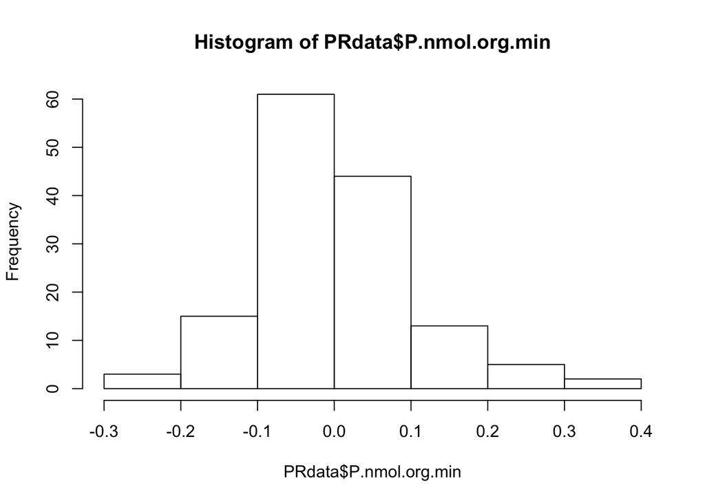

```r
hist(PRdata$P.nmol.org.min)
```

Generate plots.

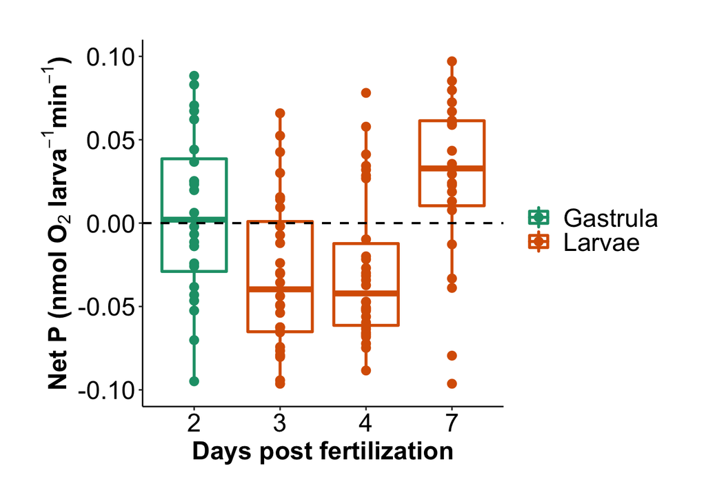

```r
Pplot1<-ggplot(data=PRdata, aes(x=dpf, y=P.nmol.org.min, colour=Stage, group=interaction(Stage, dpf))) +
  geom_boxplot(position=position_dodge(0.9), lwd=1)+
  geom_jitter(shape=16, position=position_dodge(0.9), size=3)+
  geom_hline(yintercept=0, linetype="dashed", color="black", size=0.75)+
  scale_color_brewer(palette = "Dark2", breaks=c("Gastrula", "Larvae"))+
  scale_y_continuous(limits=c(-0.1, 0.1), labels = scales::number_format(accuracy = 0.01, decimal.mark = '.'))+
  xlab("Days post fertilization")+
  ylab(expression(bold(paste("Net P (nmol ", O[2], " larva"^-1, "min"^-1, ")")))) +
  theme_classic() +
  theme(text = element_text(size = 18, color="black"),
        axis.text = element_text(size = 18, color="black"),
        legend.position = "right",
        axis.title = element_text(size = 18, color="black", face="bold"),
        legend.title=element_blank(),
        legend.text = element_text(size=18),
        plot.margin=unit(c(1,1,1,1), "cm"),
        axis.title.y = element_text(margin = margin(t = 0, r = 1, b = 0, l = 1)),
        axis.title.x = element_text(margin = margin(t = 3, r = 0, b = 0, l = 0))); Pplot1
```

```r
Pplot2<-Pplot1+theme(legend.position="none")

ggsave("../../Ahya2020/Figures/Respiration/ahya_P.pdf", plot=Pplot2, height=8, width=7, units = c("in"), dpi=300) #output figure
```

Generate mean table.

```r
meanP <- plyr::ddply(PRdata, c("Stage", "dpf"), summarise,
                   N    = length(P.nmol.org.min[!is.na(P.nmol.org.min)]),
                   mean = mean(P.nmol.org.min, na.rm=TRUE),
                   sd   = sd(P.nmol.org.min, na.rm=TRUE),
                   se   = sd / sqrt(N)
); meanP
```

```
##      Stage dpf  N        mean         sd         se
## 1 Gastrula   2 29 -0.01737435 0.08854780 0.01644291
## 2   Larvae   3 39 -0.04426597 0.08807428 0.01410317
## 3   Larvae   4 37 -0.02176315 0.07219061 0.01186806
## 4   Larvae   7 38  0.07994706 0.12850382 0.02084607
```

### *Gross Photosynthesis*

Examine data.

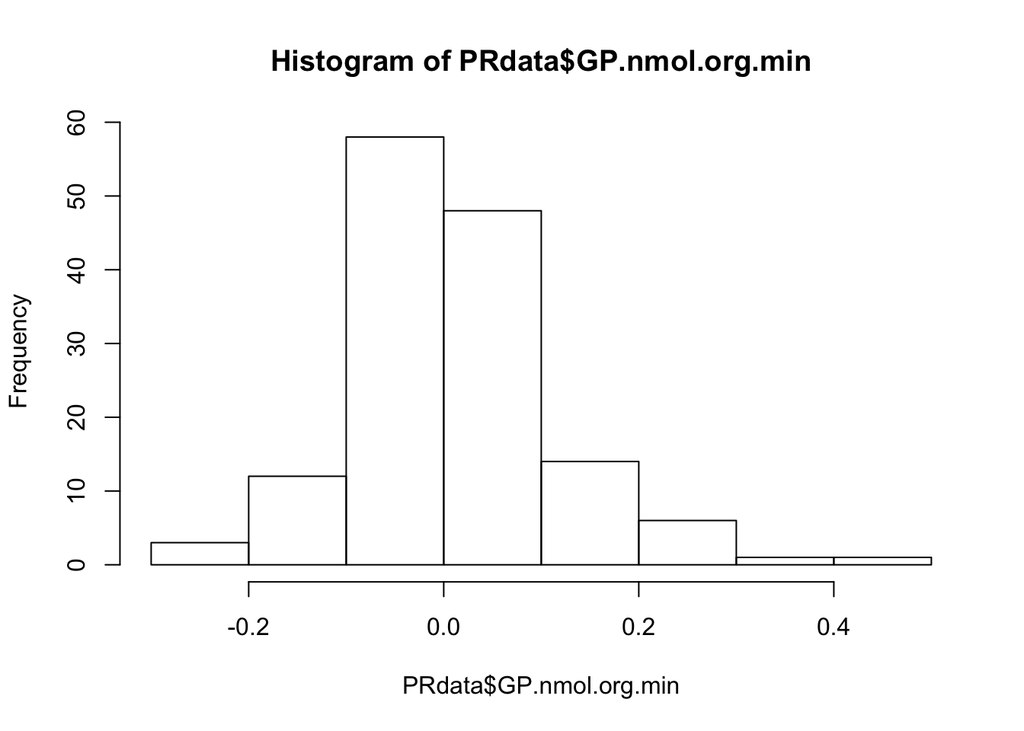

```r
hist(PRdata$GP.nmol.org.min)
```

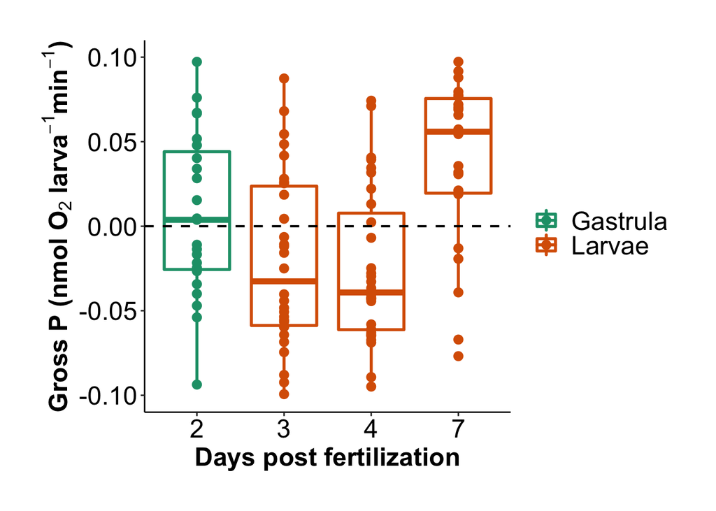

```r
GPplot1<-ggplot(data=PRdata, aes(x=dpf, y=GP.nmol.org.min, colour=Stage, group=interaction(Stage, dpf))) +
  geom_boxplot(position=position_dodge(0.9), lwd=1)+
  geom_jitter(shape=16, position=position_dodge(0.9), size=3)+
  geom_hline(yintercept=0, linetype="dashed", color="black", size=0.75)+
  scale_color_brewer(palette = "Dark2", breaks=c("Gastrula", "Larvae"))+
  scale_y_continuous(limits=c(-0.1, 0.1), labels = scales::number_format(accuracy = 0.01, decimal.mark = '.'))+
  xlab("Days post fertilization")+
  ylab(expression(bold(paste("Gross P (nmol ", O[2], " larva"^-1, "min"^-1, ")")))) +
  theme_classic() +
  theme(text = element_text(size = 18, color="black"),
        axis.text = element_text(size = 18, color="black"),
        legend.position = "right",
        axis.title = element_text(size = 18, color="black", face="bold"),
        legend.title=element_blank(),
        legend.text = element_text(size=18),
        plot.margin=unit(c(1,1,1,1), "cm"),
        axis.title.y = element_text(margin = margin(t = 0, r = 1, b = 0, l = 1)),
        axis.title.x = element_text(margin = margin(t = 3, r = 0, b = 0, l = 0))); GPplot1
```

```r
GPplot2<-GPplot1+theme(legend.position="none")

ggsave("../../Ahya2020/Figures/Respiration/ahya_GP.pdf", plot=GPplot2, height=8, width=7, units = c("in"), dpi=300) #output figure
```

Generate mean table.

```r
meanGP <- plyr::ddply(PRdata, c("Stage", "dpf"), summarise,
                   N    = length(GP.nmol.org.min[!is.na(GP.nmol.org.min)]),
                   mean = mean(GP.nmol.org.min, na.rm=TRUE),
                   sd   = sd(GP.nmol.org.min, na.rm=TRUE),
                   se   = sd / sqrt(N)
); meanGP
```

```
##      Stage dpf  N         mean         sd         se
## 1 Gastrula   2 29 -0.009719047 0.08556150 0.01588837
## 2   Larvae   3 39 -0.029210134 0.08962522 0.01435152
## 3   Larvae   4 37 -0.017200298 0.07235773 0.01189554
## 4   Larvae   7 38  0.093831186 0.13040299 0.02115416
```

### *Gross Photosynthesis:Respiration ratio*

Examine data and remove outliers.

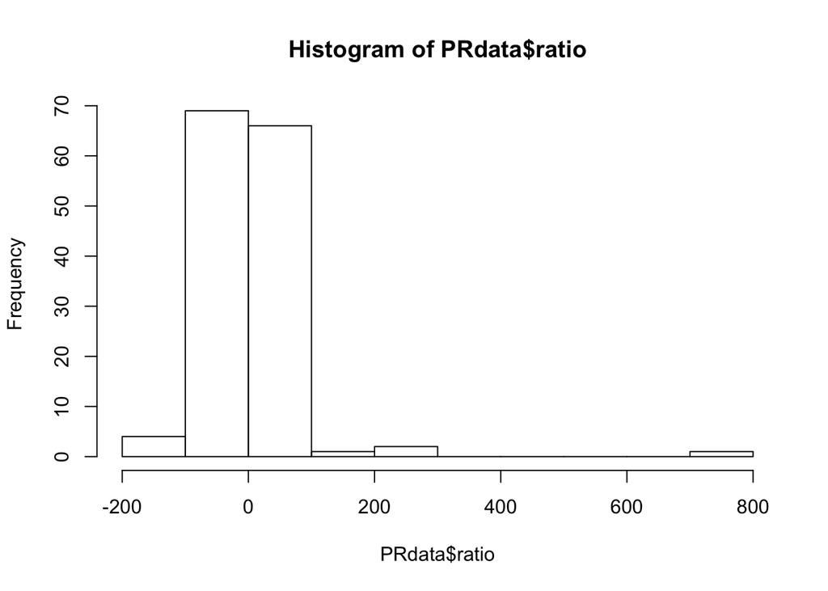

```r
hist(PRdata$ratio)
```

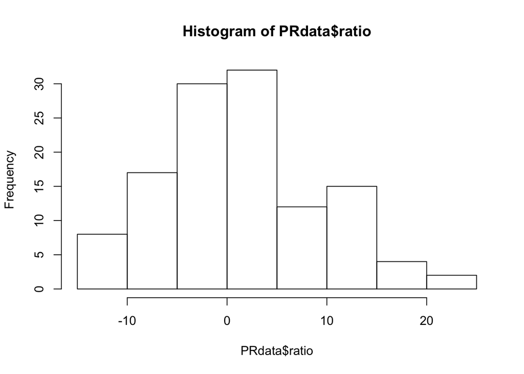

```r
PRdata<-PRdata%>%filter(ratio > -15 & ratio < 25)

hist(PRdata$ratio)
```

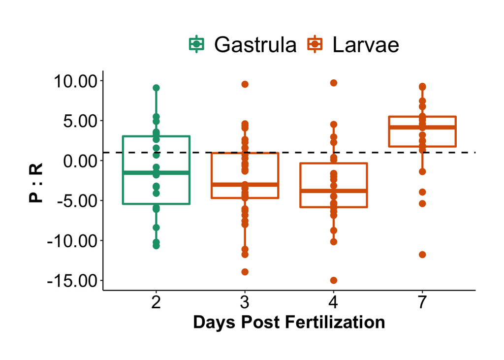

```r
PRplot1<-ggplot(data=PRdata, aes(x=dpf, y=ratio, colour=Stage, group=interaction(Stage, dpf))) +
  geom_boxplot(position=position_dodge(0.9), lwd=1)+
  geom_jitter(shape=16, position=position_dodge(0.9), size=3)+
  scale_color_brewer(palette = "Dark2", breaks=c("Gastrula", "Larvae", "Juvenile"))+
  geom_hline(yintercept=1, linetype="dashed", color="black", size=0.75)+
  scale_y_continuous(limits=c(-15, 10), labels = scales::number_format(accuracy = 0.01, decimal.mark = '.'))+
  ylab(expression(bold(paste("P : R ")))) +
  xlab("Days Post Fertilization") +
  theme_classic() +
  theme(text = element_text(size = 18, color="black"),
        axis.text = element_text(size = 18, color="black"),
        legend.position = "top",
        axis.title = element_text(size = 18, color="black", face="bold"),
        legend.title=element_blank(),
        legend.text = element_text(size=22),
        plot.margin=unit(c(1,1,1,1), "cm"),
        axis.title.y = element_text(margin = margin(t = 0, r = 1, b = 0, l = 1)),
        axis.title.x = element_text(margin = margin(t = 3, r = 0, b = 0, l = 0))); PRplot1
```

```r
PRplot2<-PRplot1+theme(legend.position="right")

ggsave("../../Ahya2020/Figures/Respiration/ahya_PR.pdf", plot=PRplot1, height=8, width=8, units = c("in"), dpi=300) #output figure
```

Generate mean table.

```r
meanPR <- plyr::ddply(PRdata, c("Stage", "dpf"), summarise,
                   N    = length(ratio[!is.na(ratio)]),
                   mean = mean(ratio, na.rm=TRUE),
                   sd   = sd(ratio, na.rm=TRUE),
                   se   = sd / sqrt(N)
); meanPR
```

```
##      Stage dpf  N       mean       sd        se
## 1 Gastrula   2 26  0.8381313 7.159402 1.4040743
## 2   Larvae   3 35 -1.6475483 5.853658 0.9894488
## 3   Larvae   4 27  0.4557506 9.260012 1.7820901
## 4   Larvae   7 32  6.3853793 6.877131 1.2157165
```

### *Plot Panels*

Combine plots above into a single panel.

```r
ahya_respiration<-plot_grid(Rplot2, Pplot2, GPplot2, PRplot2, labels = c("A", "B", "C", "D"), label_size=18, ncol=4, nrow=1, rel_heights= c(1,1,1,1), rel_widths = c(0.75,0.75,0.75,1), align="h")

ggsave(filename="../../Ahya2020/Figures/Respiration/ahya_PR_panel.pdf", plot=ahya_respiration, dpi=300, width=24, height=6, units="in")
```

## **Analysis: Larvae**

### *Respiration*

Build linear mixed effect model and examine for Respiration.

```r
Rmodel1<-lmer(R.nmol.org.min~Stage*dpf + (1|Run/dpf), data=PRdata) #run nested within day
anova(Rmodel1, type="II")
```

```
## Type II Analysis of Variance Table with Satterthwaite's method
##               Sum Sq    Mean Sq NumDF  DenDF F value Pr(>F)
## Stage     0.00022676 0.00022676     1 3.5090  2.3240 0.2118
## dpf       0.00065807 0.00032904     2 3.2831  3.3722 0.1600
## Stage:dpf
```

Check assumptions of model for residual normality and variance.

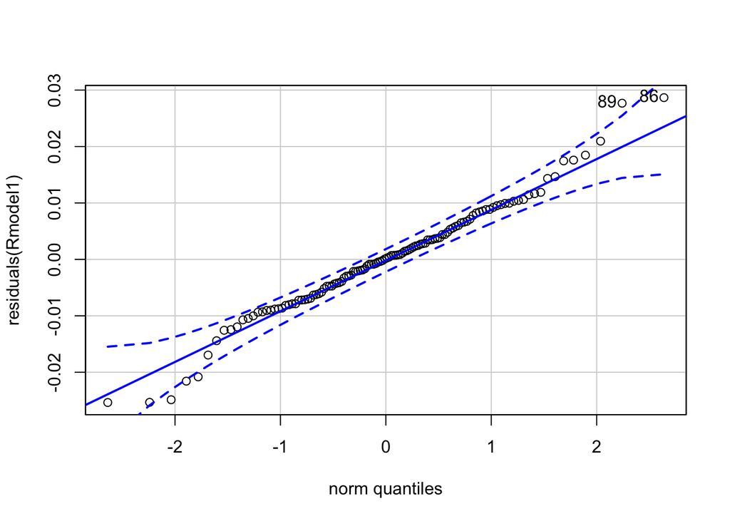

```
## [1] 86 89
```

```r
qqPlot(residuals(Rmodel1))
```

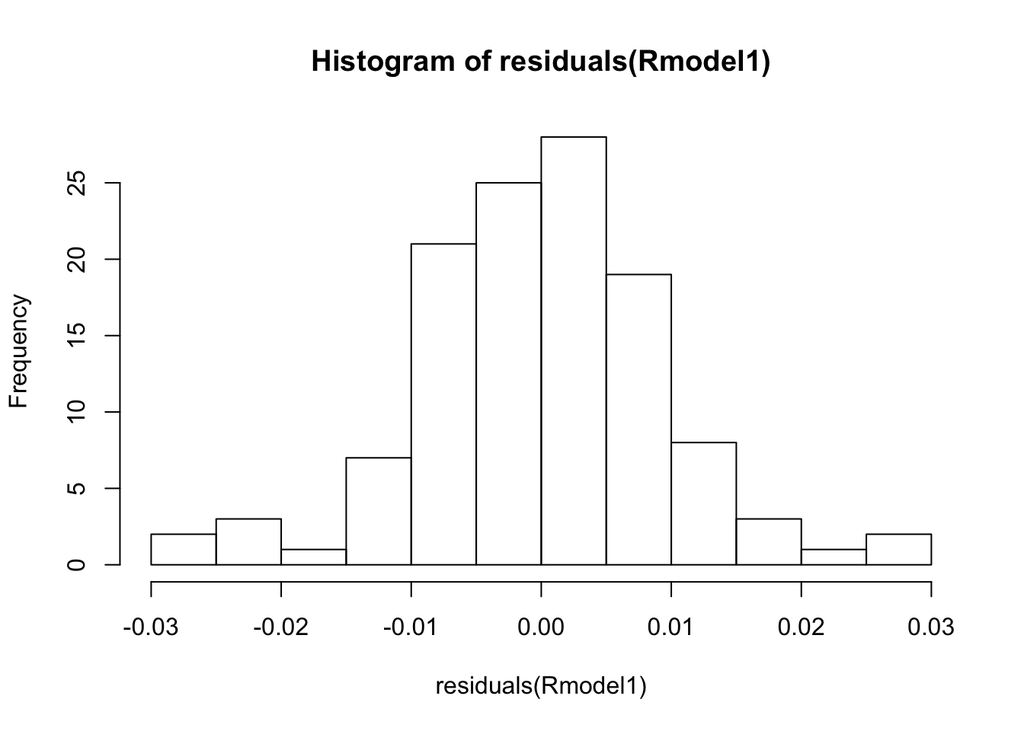

```r
hist(residuals(Rmodel1))
```

```r
leveneTest(residuals(Rmodel1)~Stage * dpf, data=PRdata)
```

```
## Levene's Test for Homogeneity of Variance (center = median)
##        Df F value  Pr(>F)
## group   3  3.8719 0.01111 *
##       116
## ---
## Signif. codes:  0 '***' 0.001 '**' 0.01 '*' 0.05 '.' 0.1 ' ' 1
```

There is no significant effect of stage or dfp on respiration.

### *Net Photosynthesis*

Build linear mixed effect model and examine for Net Photosynthesis.

```r
Pmodel1<-lmer(P.nmol.org.min~Stage*dpf + (1|Run/dpf), data=PRdata)
anova(Pmodel1, type="II")
```

```
## Type II Analysis of Variance Table with Satterthwaite's method
##             Sum Sq  Mean Sq NumDF  DenDF F value Pr(>F)
## Stage     0.025271 0.025271     1 4.0005  3.5832 0.1313
## dpf       0.031016 0.015508     2 3.8802  2.1989 0.2299
## Stage:dpf
```

Check assumptions of model for residual normality and variance.

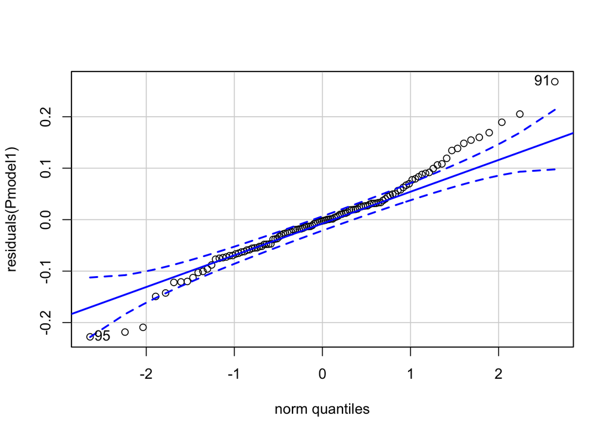

```
## [1] 91 95
```

```r
qqPlot(residuals(Pmodel1))
```

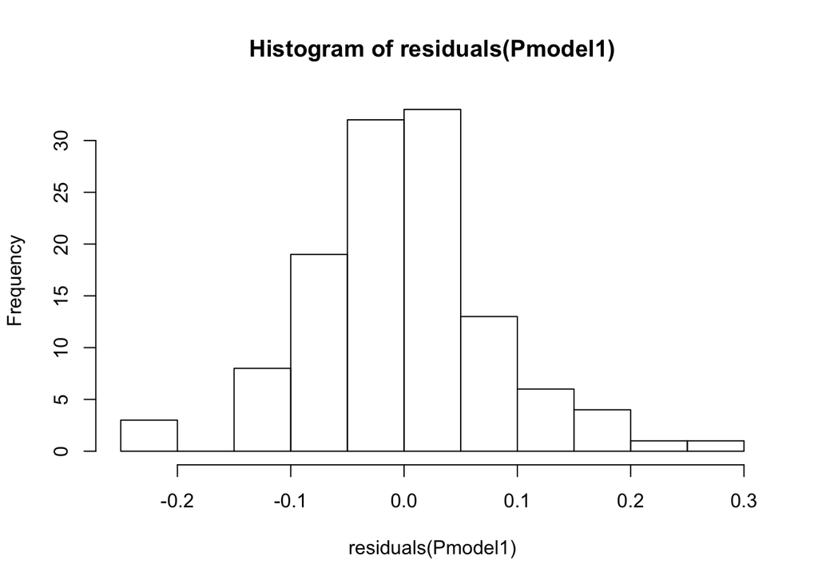

```r
hist(residuals(Pmodel1))
```

```r
leveneTest(residuals(Pmodel1)~Stage * dpf, data=PRdata)
```

```
## Levene's Test for Homogeneity of Variance (center = median)
##        Df F value Pr(>F)
## group   3  1.8895 0.1352
##       116
```

Stage and dpf are not signficant in analysis of net photosynthesis.

### *Gross Photosynthesis*

Build linear mixed effect model and examine for Gross Photosynthesis.

```r
GPmodel1<-lmer(GP.nmol.org.min~Stage*dpf + (1|Run/dpf), data=PRdata)
anova(GPmodel1, type="II")
```

```
## Type II Analysis of Variance Table with Satterthwaite's method
##             Sum Sq  Mean Sq NumDF  DenDF F value Pr(>F)
## Stage     0.029296 0.029296     1 4.0163  4.1228 0.1119
## dpf       0.034700 0.017350     2 3.8907  2.4416 0.2056
## Stage:dpf
```

Check assumptions of model for residual normality and variance.

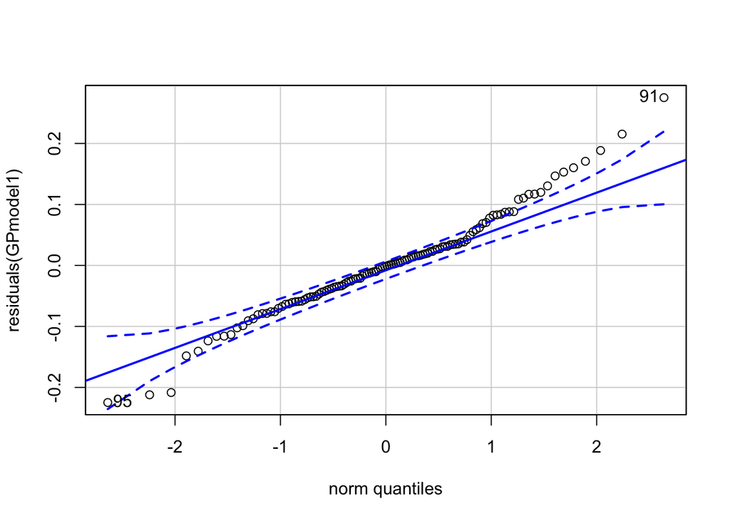

```
## [1] 91 95
```

```r
qqPlot(residuals(GPmodel1))
```

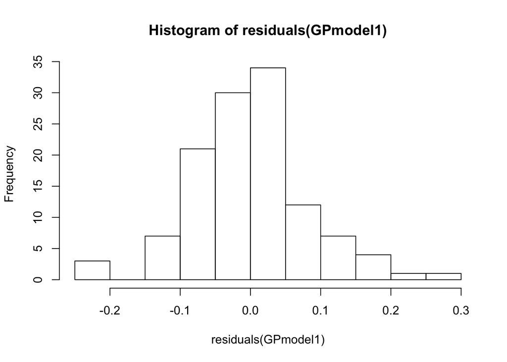

```r
hist(residuals(GPmodel1))
```

```r
leveneTest(residuals(GPmodel1)~Stage * dpf, data=PRdata)
```

```
## Levene's Test for Homogeneity of Variance (center = median)
##        Df F value Pr(>F)
## group   3  2.5213 0.0613 .
##       116
## ---
## Signif. codes:  0 '***' 0.001 '**' 0.01 '*' 0.05 '.' 0.1 ' ' 1
```

Stage and dpf are not significant for gross photosynthesis.

### *P:R*

Build linear mixed effect model and examine for P:R ratio (gross photosynthesis : respiration)

```r
PRmodel1<-lmer(ratio~Stage*dpf + (1|Run/dpf), data=PRdata)
anova(PRmodel1, type="II")
```

```
## Type II Analysis of Variance Table with Satterthwaite's method
##           Sum Sq Mean Sq NumDF  DenDF F value Pr(>F)
## Stage     126.49  126.49     1 3.9489  2.6808 0.1778
## dpf       237.03  118.52     2 3.7743  2.5118 0.2025
## Stage:dpf
```

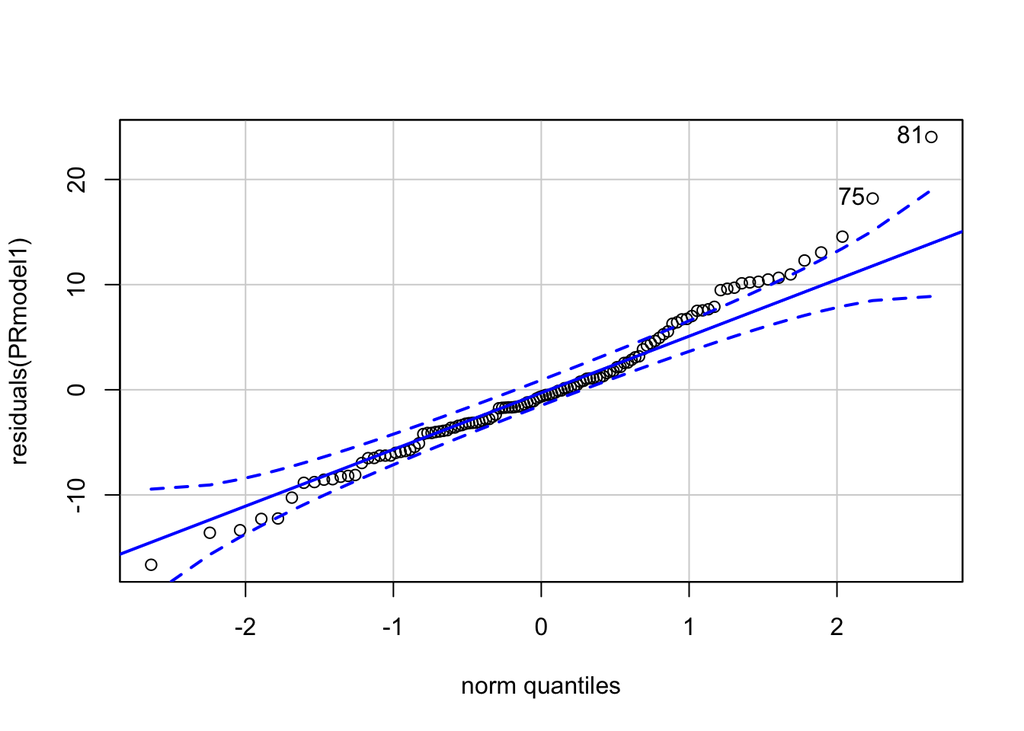

```
## [1] 81 75
```

```r
qqPlot(residuals(PRmodel1))
```

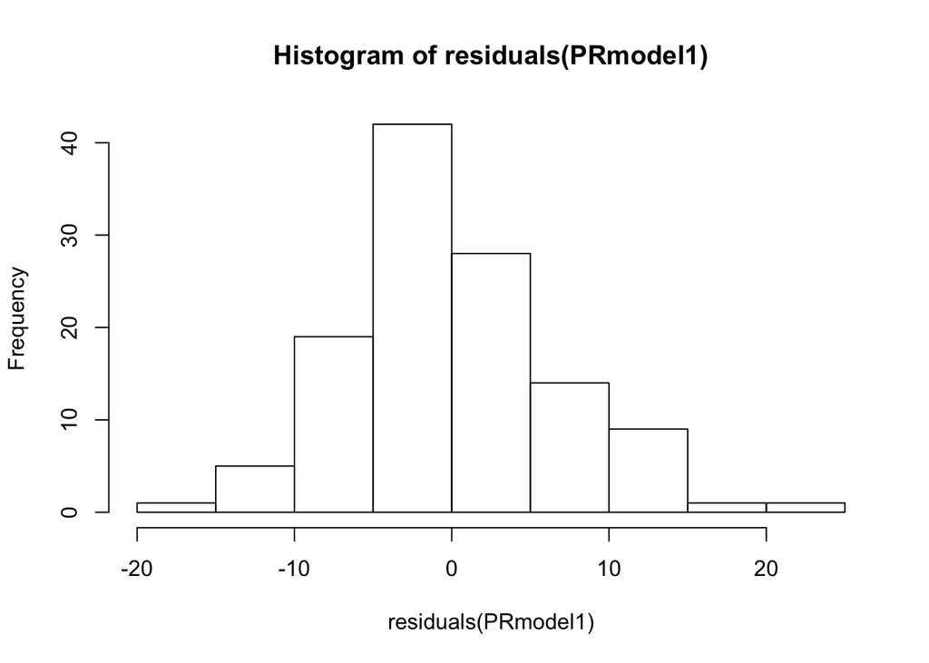

```r
hist(residuals(PRmodel1))
```

```r
leveneTest(residuals(PRmodel1)~Stage * dpf, data=PRdata)
```

```
## Levene's Test for Homogeneity of Variance (center = median)
##        Df F value Pr(>F)
## group   3  0.3316 0.8025
##       116
```

No significant effect of lifestage or dpf on P:R.